# Classification and Cross-validation

Classification methods are an example of supervised statistical learning. Familiar methods such as logistic regression can be used as a classification method. Dimension reduction methods, such as linear discriminant analysis, can also be used in this context. In classification, the outcome variable is typically binary, coded as `1` or `0`, but could also have more than two levels. It just needs to be categorical. The goal of a classification model is to take a new point and determine if that point should be classified as a `1` or a `0`.

## Simulate data with three clusters from multivariate normal distribution

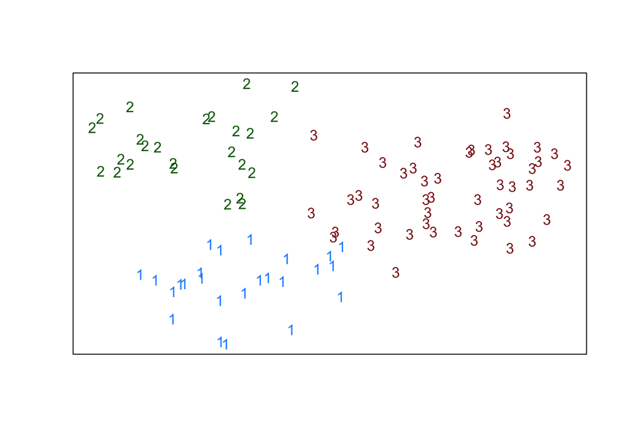

```r
set.seed(10)
# Generate three clusters of size 25, 25 and 50 from three different
# multivariate normal distributions
cluster1 <- rmnorm(n=25, mean=c(.3,.2), varcov=diag(2)*.025)
cluster2 <- rmnorm(n=25, mean=c(.15,.75), varcov=diag(2)*.025)
cluster3 <- rmnorm(n=50, mean=c(.75,.6), varcov=diag(2)*.03)
# Set up plot window
plot(rbind(cluster1, cluster2, cluster3),
     type='n', axes=F, xlab='', ylab='')
# Add different colored points for each cluster
points(cluster1, pch='1',col='dodgerblue')
points(cluster2, pch='2',col='darkgreen')
points(cluster3, pch='3',col='firebrick4')
# Draw a box around the plot
box()
```

## Logistic regression

Logistic regression is a type of generalize linear model that models binary or binomial data. Thus, to use this method, our outcome variable can take on only two possible values, call these `1` and `0`. Logistic regression will produce a predicted probability of a `1` outcome, which can be converted into a predicted classification into a cluster.

We will then use our model to classify new points at (.2, .7), (.45, .35), (.48, .3), and (.9, .4).

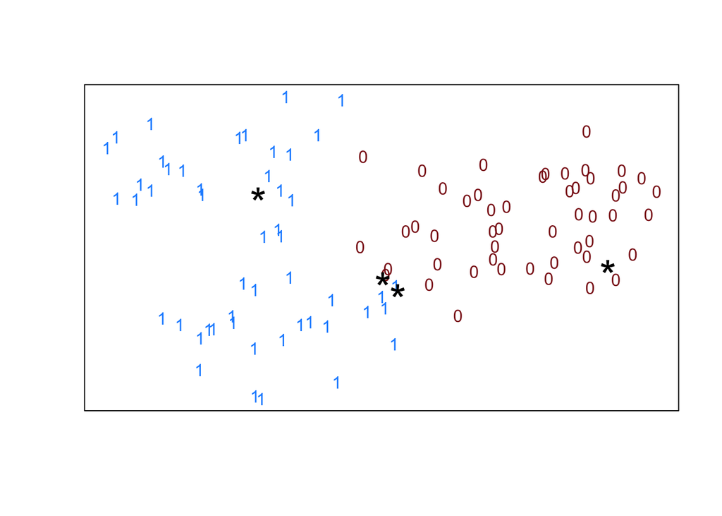

```r
pred.points <- data.frame(
  x = c(.2,.45,.48,.9),
  y = c(.7,.35,.3,.4)
  )

# To demonstrate logistic regression,
# treat clusters 1 and 2 as if they're the same cluster
plot(rbind(cluster1,cluster2,cluster3),type='n',axes=F,xlab='', ylab='')
points(cluster1,pch='1',col='dodgerblue')
points(cluster2,pch='1',col='dodgerblue')
points(cluster3,pch='0',col='firebrick4')
# Add new data points
points(pred.points, pch='*', cex=2.5)
box()
```

```r
labels <- (rep(c(1, 0), each = 50))
combined <- rbind(cluster1, cluster2, cluster3)
supervised <- as.data.frame(cbind(labels, combined))
colnames(supervised)[2:3] <- c('x','y')
head(supervised)
```

```
##   labels          x         y
## 1      1 0.30296403 0.1708671
## 2      1 0.08317360 0.1052633
## 3      1 0.34657167 0.2616319
## 4      1 0.10898638 0.1424978
## 5      1 0.04280047 0.1594472
## 6      1 0.47420664 0.3194995
```

The `glm` function will fit a logistic regression model. The `family = 'binomial'` argument tells R to fit logistic regression. By default, `family = 'gaussian'`, and `glm` will fit a usual linear model.

```r
logistic <- glm(labels ~ x + y, data = supervised, family='binomial')
summary(logistic)
```

```
##
## Call:
## glm(formula = labels ~ x + y, family = "binomial", data = supervised)
##
## Deviance Residuals:
##      Min        1Q    Median        3Q       Max
## -1.93887  -0.00046   0.00000   0.00285   1.44209
##
## Coefficients:
##             Estimate Std. Error z value Pr(>|z|)
## (Intercept)   23.898     11.813   2.023   0.0431 *
## x            -47.482     23.973  -1.981   0.0476 *
## y             -6.214      3.456  -1.798   0.0722 .
## ---
## Signif. codes:  0 '***' 0.001 '**' 0.01 '*' 0.05 '.' 0.1 ' ' 1
##
## (Dispersion parameter for binomial family taken to be 1)
##
##     Null deviance: 138.629  on 99  degrees of freedom
## Residual deviance:  13.024  on 97  degrees of freedom
## AIC: 19.024
##
## Number of Fisher Scoring iterations: 10
```

Use model to classify new points at (.2, .7), (.45, .35), (.48, .3), and (.9, .4). When calculating predictions, we need to specify that we want the predicted probabilities with the `type = ’response`` argument. (Otherwise, the calculated predictions are reported on a different scale.)

```r
kable(
  cbind(
    pred.points,
    round(predict(logistic, pred.points, type='response'), 3)
  ),
  col.names = c('x', 'y', 'Prob[Val = 1]')
  )
```

| x | y | Prob[Val = 1] |
| --- | --- | --- |
| 0.20 | 0.70 | 1.000 |
| 0.45 | 0.35 | 0.588 |
| 0.48 | 0.30 | 0.319 |
| 0.90 | 0.40 | 0.000 |

# Decision tree

```r
tree1 <- rpart(labels ~., data = supervised, method = 'class')
print(tree1)
```

```
## n= 100
##
## node), split, n, loss, yval, (yprob)
##       * denotes terminal node
##
## 1) root 100 50 0 (0.50000000 0.50000000)
##   2) x>=0.4849104 46  0 0 (1.00000000 0.00000000) *
##   3) x< 0.4849104 54  4 1 (0.07407407 0.92592593) *
```

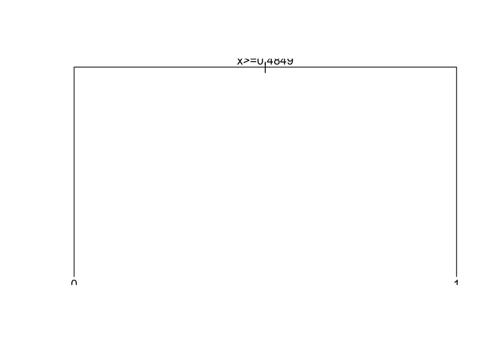

```r
plot(tree1)
text(tree1)
```

Compare tree predictions to logistic regression predictions:

| x | y | Logistic Pred | Tree Pred |
| --- | --- | --- | --- |
| 0.20 | 0.70 | 1.000 | 0.926 |
| 0.45 | 0.35 | 0.588 | 0.926 |
| 0.48 | 0.30 | 0.319 | 0.926 |
| 0.90 | 0.40 | 0.000 | 0.000 |

## Cross-validation to assess predictive power

Note that, rather than first splitting our data into training and testing sets, we used the entire data set to fit the model. Thus, we need to use a method such as cross-validation to assess how well the model predicts new data points.

```r
# Set parameters
num.folds <- 3 # Number of folds
num.obs <- nrow(supervised) # Sample size
pred.vector <- rep(0, num.obs) # Vector to store predictions

# Create folds by
# assigning a fold index (1, 2, or 3) to each observation
set.seed(052022)
fold.ids <- sample(num.folds, num.obs, replace = TRUE)

# For each fold, fit the model on data not in the fold,
# then test predictions on fold
for(i in 1:num.folds){
  train <- supervised[fold.ids != i,]
  test <- supervised[fold.ids == i,]
  mod <- glm(labels ~ x + y, data = train, family='binomial')
  pred.vector[fold.ids == i] <- predict(mod, test, type = 'response')
}
```

```
## Warning: glm.fit: algorithm did not converge
```

```
## Warning: glm.fit: fitted probabilities numerically 0 or 1 occurred
```

```r
# Calculate classification error = proportion mis-classified
# Classification created by rounding probability
# (prob < 0.5 classified as "0"; prob > 0.5 classified as "1")
CE <- 1 - mean(round(pred.vector) == supervised$labels)
CE
```

```
## [1] 0.03
```

Note the warnings that were displayed — since the data exhibit *complete separation* on the x-y plane, the algorithm that fits a logistic regression will not converge. Essentially, the variables `x` and `y` completely predict whether an observation is classified as `0` or `1` in the data set to which the model is fit. In that case, coefficient estimates may be infinite or may not even exist.

We can do the same for the decision tree model:

```r
pred2.vector <- rep(0, num.obs) # Vector to store predictions

# For each fold, fit the model on data not in the fold,
# then test predictions on fold
for(i in 1:num.folds){
  train <- supervised[fold.ids != i,]
  test <- supervised[fold.ids == i,]
  mod2 <- rpart(labels ~., data = train, method = 'class')
  pred2.vector[fold.ids == i] <- predict(mod2, test)[,2]
}

# Calculate classification error = proportion mis-classified
# Classification created by rounding probability
# (prob < 0.5 classified as "0"; prob > 0.5 classified as "1")
CE2 <- 1 - mean(round(pred.vector) == supervised$labels)
CE2
```

```
## [1] 0.03
```

## Cross-validation with Seattle housing data set

Let’s try this on the Seattle housing data set where we convert the quantitative outcome variable `price` to a `1` if the price is greater than $1,000,000, `0` otherwise.

```r
Seattle <- read.csv('https://math.montana.edu/shancock/data/SeattleHousing.csv')
Seattle$million <- as.numeric(Seattle$price > 1000000)
num.folds <- 3
num.houses <- nrow(Seattle)
pred.vector <- rep(0, num.houses)

fold.ids <- sample(num.folds, num.houses, replace=TRUE)

for (i in 1:num.folds){
  train <- Seattle[fold.ids != i,]
  test <- Seattle[fold.ids == i,]
  mod3 <- glm(million ~ bedrooms + bathrooms + sqft_living +
                    sqft_lot + waterfront + floors,
                  data = train, family='binomial')
  pred.vector[fold.ids == i] <- predict(mod3, test, type='response')
}

CE3 <- 1 - mean(round(pred.vector) == Seattle$million)
CE3
```

```
## [1] 0.08975834
```

## Attribution

Example adapted from Dr. Hoegh’s STAT 408 notes.